# Statistical study of relationship

## Correlation and regression analysis (CRA)

One of the tasks of statistics is the study of existing relationships between various socio-economic phenomena and processes.

In studying these interrelationships, cause-and-effect relationships between phenomena or their attributes are identified, in which a change in the cause leads to a change in the effect.

Since the same socio-economic phenomenon can be influenced by various factors, it is necessary to determine the impact of the main factors, abstracting from the secondary ones.

## Classification of traits

Traits **by their influence for the study of relationships** are categorized into:

- **factorial**, traits that influence other, related traits $x$;
- **resultant**, attributes that change under the influence of factor attributes $y_x$.

Regression analysis consists in determining the analytical expression of the relationship between the attributes under study, and correlation analysis consists in determining the closeness of the relationship between these attributes.

## Types of dependence

There are different types of dependence between traits:

- **Functional**. At **functional dependence** each value of a factor attribute corresponds to only one value of the resultant attribute.

$$y_i = f(x_i)$$

- **Stochastic**. At **stochastic dependence** 2 or more values of the resultant trait can correspond to each value of the factor trait.

$$\hat{y}_i = f(x_i) + \varepsilon_i$$

where:

- $\hat{y}_i$ - calculated value of the resultant;
- $f(x_i)$ - part of the value of the resultant sign, formed under the influence of the factors taken into account;
- $\varepsilon_i$ - part of the value of the resultant characteristic formed under the influence of random (unaccounted) factors.

**Correlation is a special case of stochastic dependence.**

## Types of correlation

There are **types of correlation between traits** :

- **pair correlation**, in which the dependence of one resultant trait on one factor trait or the relationship between two factor traits is studied;
- **partial correlation**, in which the dependence of one resultant trait on one factor trait is studied, while the value of other factor traits is fixed;
- **multiple correlation**, in which the dependence of one resultant trait on two or more factor traits is studied.

Relationships between the signs are classified by analytical expression, direction and degree of closeness.

## Types of correlation

**Based on analytical expression**:

- **linear** correlation.

$$y_x = a + bx$$

- **nonlinear** relationship.

$$\begin{align}
\text{Power correlation: }& y_x = \: ax^b \\
\text{Logarithmic: }& y_x = \: a+b \cdot \log(x) \\
\text{Exponential: }& y_x = \: a \cdot b^x \\
\text{Hyperbolic: }& y_x = \: a + \frac{b}{x}
\end{align}$$

## Types of correlation dependence

**The direction** of the correlation is distinguished:

- **Direct** correlation. Direct relationship, in which with an increase (decrease) in the values of the factor attribute, the values of the resultant attribute increase (decrease).
- **Inverse** relationship. In the case of feedback between the signs, the value of the resultant sign changes under the influence of the factor sign in the opposite direction.

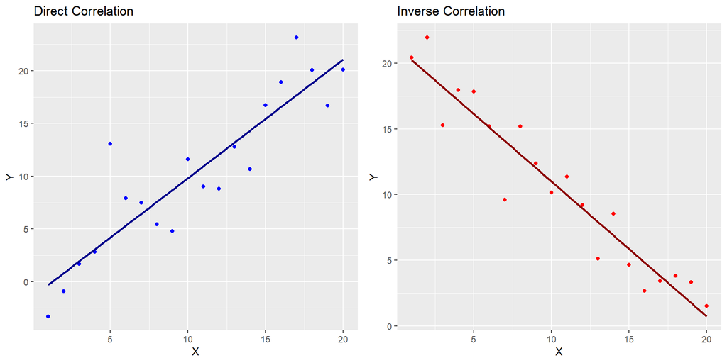

## Basic prerequisites for using regression analysis

- Sufficient volume of observations (at least 6 units).
- Homogeneity of the units under study.
- The random component of the model $\varepsilon_i$ (residuals) has a normal distribution with mathematical expectation equal to zero and constant variance (Residuals $\varepsilon_i$ should not depend on the values of the factor $x_i$).
- The residuals $\varepsilon_i$ must be uncorrelated with each other.

## Stages of building regression models

1. Selection of the formula for the relationship between the variables $y$ and $x$:
- $y = f(x)$ (specification of the regression equation).
2. Estimation of the regression equation and checking the reliability of the obtained estimates (parameterization of the regression equation)
3. Statistical analysis of the model:
- Assessing the accuracy
- adequacy of the model (determination of statistical significance of the coefficient of determination, investigation of the random component of $\varepsilon_i$).